# Forecasting Production

# [Return to Book Homepage](http://mindymallory.github.io/PriceAnalysis/)

# Introduction

The preceding chapters have served as a background about agricultural markets, and important informational events that drive commodity prices. Going forward, we will focus our energy on the more data and technical questions of actually forecasting elements of the balance sheet - and later, short term price changes using time-series econometric techniques. In the remainder of this chapter, the discussion and figures are all for corn.

# Forecasting Production

Our first task in forecasting a balance sheet will be to get a good estimate of production for the marketing year. As we noted before, `Production = Acreage X Yield`. To begin, we will discuss the fundamentals of estimating acreage.

# Estimating Acreage

Like many other agricultural variables we would like to forecast, our methodology for forecasting acreage depends on the time of year we are making the forecast. Prior to planting season, we can rely on recent trends in acreage from previous years, plus relative profitability of planting competing crops as measured by relative futures prices.

Historical acres planted and harvested can be found from USDA NASS.

## Steps to download historical acreage data:

> 1. Go to https://www.nass.usda.gov/Quick_Stats/Lite/index.php
> 2. Click *Crops* in the menu
> 3. In the query, choose *Field Crops*
> 4. Choose corn
> 5. Click *Acreage, Yeild, Production, and Price*
> 6. Select the years you want. Hold the Ctrl key to select multiple.
> 7. Click *Get Data*.

[figure not shown]

Figure 1: Historical Acreage Data

The following is a graph of historical corn *Planted Acres* along with the ratio of *Average Prices Received by Farmers* for corn and soybeans.

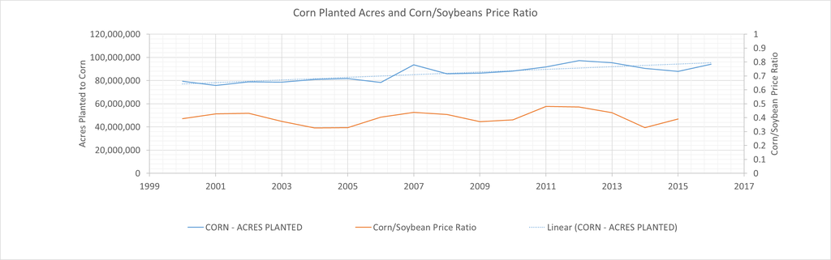

Figure 2: Corn Planted Acres and Corn/Soybean Price Ratio

Based on the information in Figure 2, one might predict a decline in corn planted acres in the spring of 2015. Although, at the time of planting, the November soybean and December corn futures prices will be the appropriate prices to use for this analysis, because they represent expected profit.

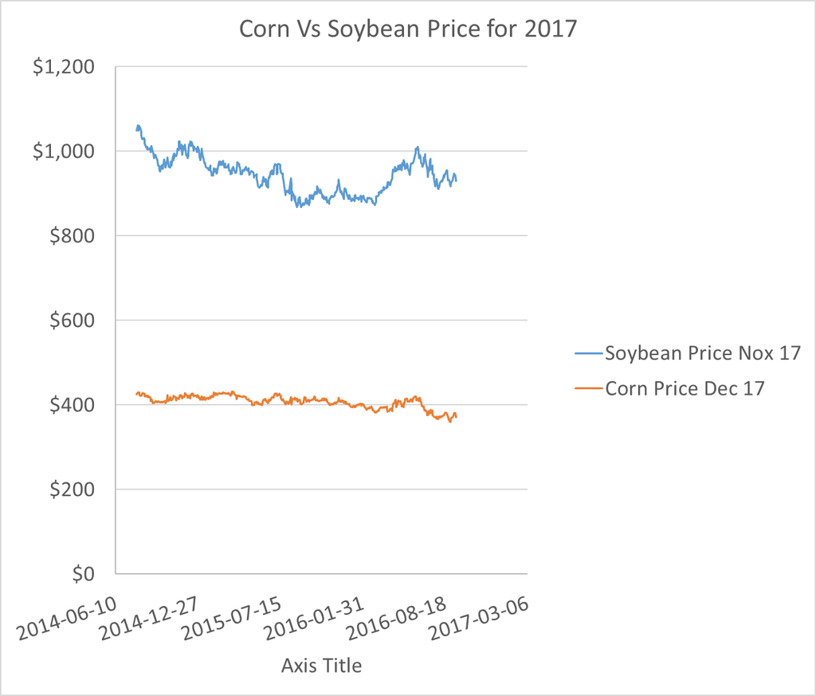

## Forecasting Harvested Acres

After forecasting *Planted Acres* one still needs to provide a forecast for *Harvested Acres*. Figure 4 shows historical trends in *Harvested Acres* relative to *Planted Acres*. The difference between these two variables is provided in grey with units along the right axis for convenience.

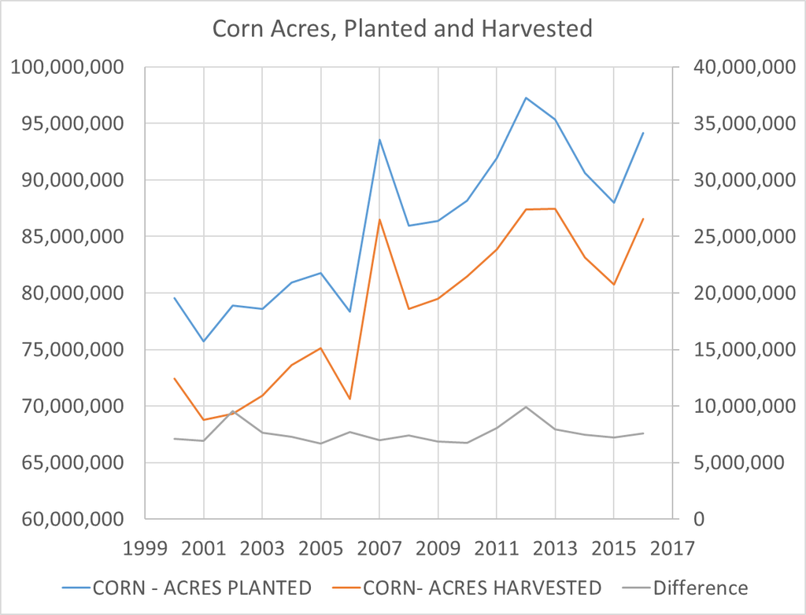

Figure 4: Corn Planted Acres and Harvested Acres

# Forecasting Yield

Just like in forecasting acreage, we have different procedures for forecasting yield prior to planting. Before the summer growing season gets underway, trend yield. The trouble is, where to start?

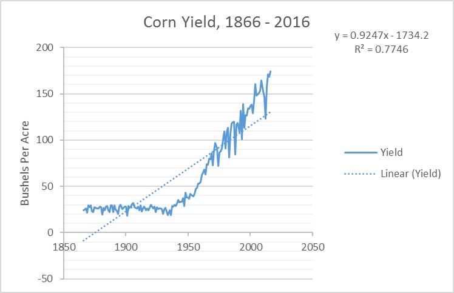

Figure 5: Historical Yields since 1866

USDA has records on yield that go back to 1866. While one often thinks more information is better when forecasting, the old yield estimates are no longer useful for forecasting current yield. Technological progress caused yields to take of in the 1950’s and they have been climbing ever since. In the forecasting world, this is called *structural change* or a *structural break*. If *structural change* has occurred, the world looks so different now than it did before the structural change that data from before the break just is not useful for forecasting going forward.

It turns out that if you estimate a trend-line beginning with 1952, with 1980, or with pretty much any date in between, you will get an estimate that is roughly similar.

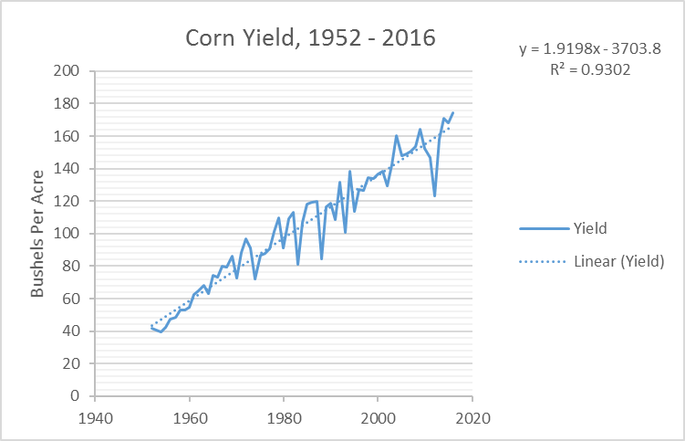

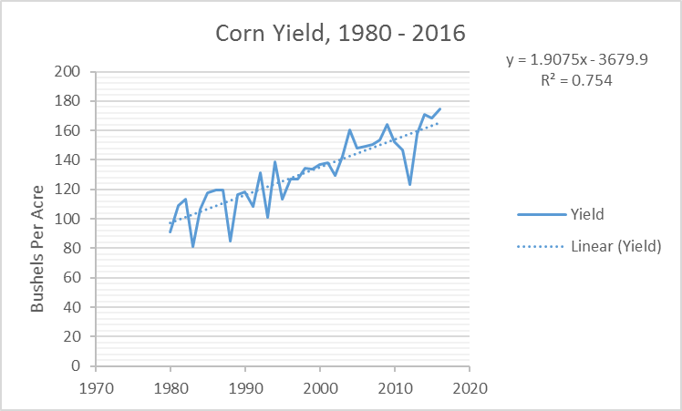

Figure 6: Historical Yields since 1952 and 1980

# Forecasting Yield during the Growing Season

The USDA has an extensive methodology to estimate yield during the growing season. Prior to August, they conduct the **Agricultural Yield Survey** (AYS) which surveys a large number of farmers and ask them to estimate yield. Beginning in August, the USDA conducts what it calls the **Objective Yield Survey**. They take samples from a relatively large number of fields and estimates yield in those fields based on various factors such as counts of plants, ears, and pods (for soybeans) (Good and Irwin 2011).

The job of the analyst who is not employed by the USDA is most likely to anticipate the yield forecast of the USDA, or possibly to make a forecast that does better than the USDA. Then the analyst can capitalize on superior private information by making a well advised business decision or earning speculative profits.

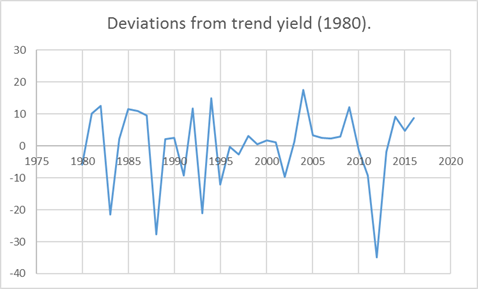

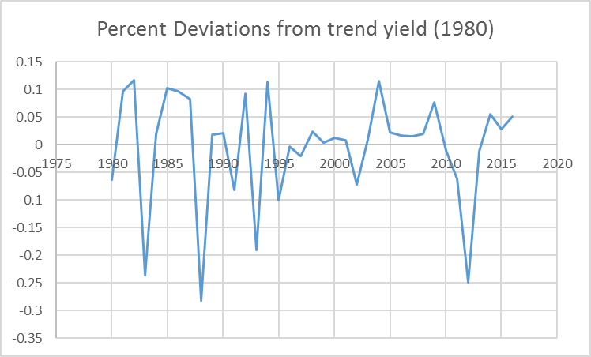

Figure 7: Deviations from Trend in both Level and Percent (using trend since 1980)

Short of an advanced agronomic model that can take into account planting date, precipitation, [growing degree days](https://en.wikipedia.org/wiki/Growing_degree-day), or ability to estimate yield from remote sensing technology (Unganai and Kogan 1998), we will have to resort to the *similar year approach*.

Analysts often estimate deviations from trend yield by finding year similar to the current one in terms of weather. The assumption is that if the weather patterns were similar then the percent deviation from trend yield should be similar as well. Note here that percent deviation is preferable so you do not need to adjust for the increasing trend in yield as you look backward to a similar year.

An alternative approach would be to use the *Crop Condition Report* and find a year in recent history that had a similar percent of the crop rated *Good/Excellent*. Figure 8 below shows how *Good* + *Excellent* crop condition ratings relate to percent deviations in trend yield. They should be at least positively correlated, and in fact starting in the late 90’s this measure began to correlate strongly with the final yeild.

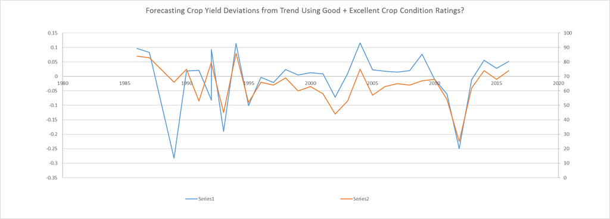

Figure 8: *Good* plus *Excellent* Crop Condition Ratings in Final Week of Reporting versus Percent Deviations in Yields

# Forecasting Production

Once you have an estimate for acreage and yield, you can multiply them to give you an estimate of production for your balance sheet forecast.

# Conclusion

In this chapter we discussed the basics of forecasting production. First we discussed forecasting acreage, then we moved on to forecasting yield both before and during the growing season. We discovered that estimating yield percent deviations from trend better than the USDA is extremely difficult. Even anticipating whether the yield forecast will go up or down is not an easy task. The *similar year method* has its limitations when used to find similar years in terms of weather or crop conditions ratings.

# Exercises

1. Use NASS data for soybeans for forecast production in a similar mannar we we did in class for corn.
2. Read and Discuss: [Early Planting and 2015 Corn Yield Prospects: How Much of an Increase?](http://farmdocdaily.illinois.edu/2015/05/early-planting-and-2015-corn-yield-prospects.html)
   - Irwin, S., D. Good, and J. Newton. “Early Planting and 2015 Corn Yield Prospects: How Much of an Increase?” farmdoc daily (5):93, Department of Agricultural and Consumer Economics, University of Illinois at Urbana-Champaign, May 20, 2015.

References

Good, D., and S. Irwin. 2011. *USDA corn and soybean acreage estimates and yield forecasts: Dispelling myths and misunderstandings* Marketing and Outlook Briefs March MOBR 11-02. Department of Agricultural; Consumer Economics, University of Illinois.

Unganai, L.S., and F.N. Kogan. 1998. “Drought monitoring and corn yield estimation in southern africa from aVHRR data.” *Remote Sensing of Environment* 63(3):219–232.